# R Notebook

```r
library(plyr)
library(ggplot2)
library(dplyr)
library(ggpubr)
library(energy)
library(tidyr)
CA <- read.csv("CA.csv", header = TRUE, stringsAsFactors = FALSE)
head(CA)
```

| Date | R.Value | D.Value |
| --- | --- | --- |
| 1895 | 22.88 | 0.87 |
| 1896 | 29.51 | 2.06 |
| 1897 | 21.95 | -0.03 |
| 1898 | 12.47 | -2.16 |
| 1899 | 24.81 | 0.51 |
| 1900 | 20.05 | 0.76 |

# Raw Data on Drought/Precipitation in California

This is a method for fitting a smooth curve between two variables versus year.The fitted points and their standard errors represent are estimated with respect to the whole curve rather than a particular estimate. So, the overall uncertainty is measured as how well the estimated curve fits the population curve.

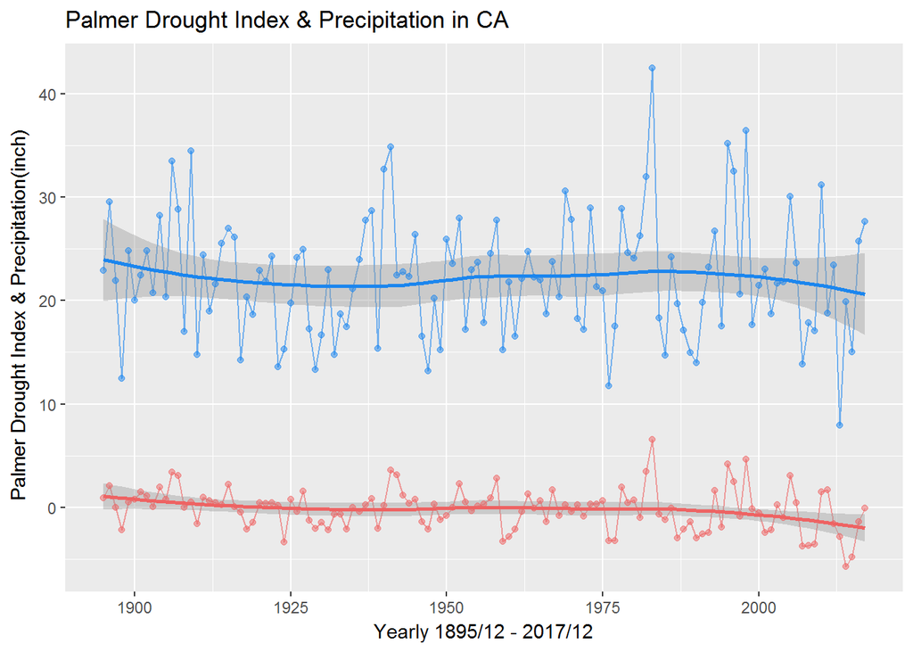

```r
#All year without grouping, fitting curve regression
#This is a method for fitting a smooth curve between two variables,
#or fitting a smooth surface between an outcome and up to four predictor variables
ggplot(data = CA)+
  geom_line(mapping = aes(x = Date , y = D.Value), color = "indianred2", alpha=0.6)+
  geom_smooth(mapping = aes(x = Date , y = D.Value), color = "indianred2", method = "loess")+
  geom_line(mapping = aes(x = Date , y = R.Value), color = "dodgerblue2", alpha=0.6)+
  geom_smooth(mapping = aes(x = Date, y = R.Value), color = "dodgerblue2", method = "loess" )+
  geom_point(mapping=aes(x = Date, y = D.Value), color = "indianred2",alpha = 0.5)+
  geom_point(mapping = aes(x = Date, y = R.Value), color = "dodgerblue2", alpha = 0.5)+
  labs(
    title = "Palmer Drought Index & Precipitation in CA",
    x ="Yearly 1895/12 - 2017/12",
    y =" Palmer Drought Index & Precipitation(inch)"
  )
```

This is a method for fitting a linear line between two variables versus year.

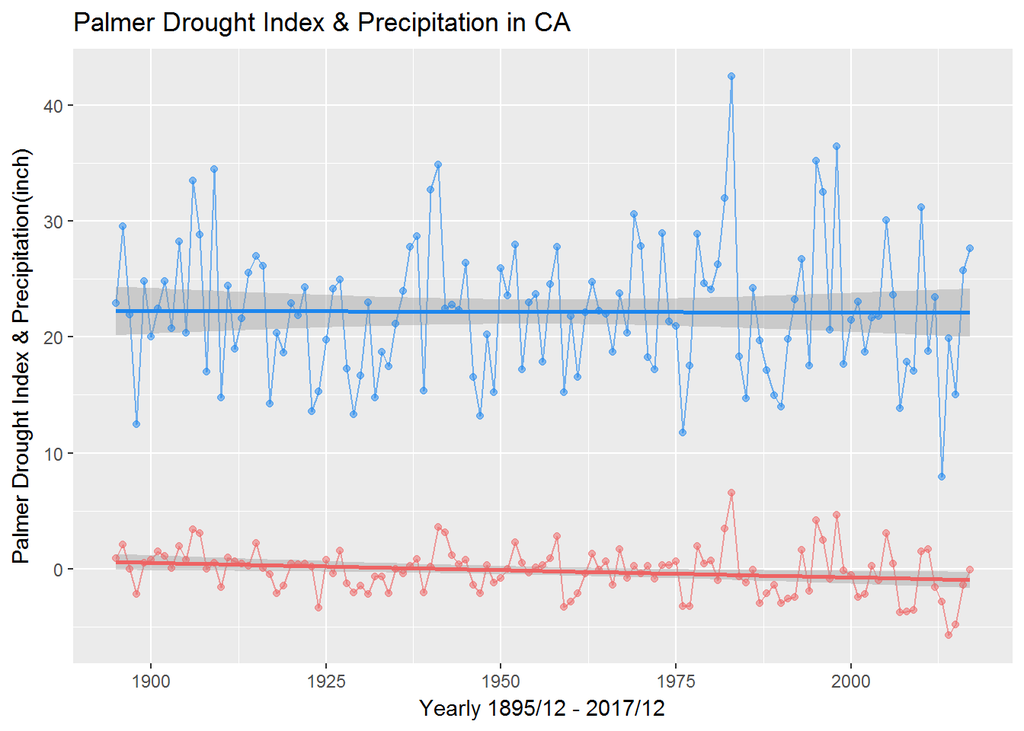

```r
#All year without grouping, fitting linear regression
ggplot(data = CA)+
  geom_line(mapping = aes(x = Date , y = D.Value), color = "indianred2", alpha=0.6)+
  geom_smooth(mapping = aes(x = Date , y = D.Value), color = "indianred2", method = "lm")+
  geom_line(mapping = aes(x = Date , y = R.Value), color = "dodgerblue2", alpha=0.6)+
  geom_smooth(mapping = aes(x = Date, y = R.Value), color = "dodgerblue2", method = "lm" )+
  geom_point(mapping=aes(x = Date, y = D.Value), color = "indianred2",alpha = 0.5)+
  geom_point(mapping = aes(x = Date, y = R.Value), color = "dodgerblue2", alpha = 0.5)+
  labs(
    title = "Palmer Drought Index & Precipitation in CA",
    x ="Yearly 1895/12 - 2017/12",
    y ="Palmer Drought Index & Precipitation(inch)"
  )
```

Linear regression summary for precipitation in CA

```r
CA_R_LM <- lm(CA$R.Value ~ CA$Date)
summary(CA_R_LM)
```

```
##
## Call:
## lm(formula = CA$R.Value ~ CA$Date)
##
## Residuals:
##      Min       1Q   Median       3Q      Max
## -14.1704  -4.4096  -0.3112   3.0314  20.3180
##
## Coefficients:
##              Estimate Std. Error t value Pr(>|t|)
## (Intercept) 24.890750  29.296085   0.850    0.397
## CA$Date     -0.001386   0.014975  -0.093    0.926
##
## Residual standard error: 5.897 on 121 degrees of freedom
## Multiple R-squared:  7.081e-05,  Adjusted R-squared:  -0.008193
## F-statistic: 0.008568 on 1 and 121 DF,  p-value: 0.9264
```

Linear regression summary for Drought in CA

```r
CA_D_LM <- lm(CA$D.Value ~ CA$Date)
summary(CA_D_LM)
```

```
##
## Call:
## lm(formula = CA$D.Value ~ CA$Date)
##
## Residuals:
##     Min      1Q  Median      3Q     Max
## -4.8519 -1.3086  0.0716  0.9025  7.0494
##
## Coefficients:
##              Estimate Std. Error t value Pr(>|t|)
## (Intercept) 24.344855   9.616998   2.531   0.0126 *
## CA$Date     -0.012539   0.004916  -2.551   0.0120 *
## ---
## Signif. codes:  0 '***' 0.001 '**' 0.01 '*' 0.05 '.' 0.1 ' ' 1
##
## Residual standard error: 1.936 on 121 degrees of freedom
## Multiple R-squared:  0.05102,    Adjusted R-squared:  0.04318
## F-statistic: 6.506 on 1 and 121 DF,  p-value: 0.012
```

# Correlation between California Drought and Precipitation

Fitting smooth curve

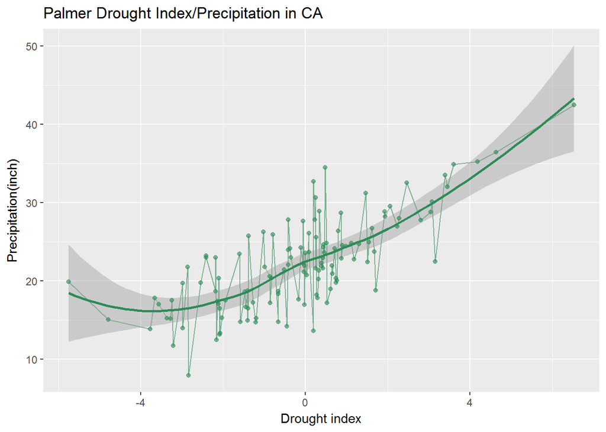

```r
ggplot(data = CA)+
  geom_line(mapping = aes(x = D.Value , y = R.Value), color = "seagreen4", alpha=0.6)+
  geom_smooth(mapping = aes(x = D.Value , y = R.Value), color = "seagreen4", method = "loess")+
  geom_point(mapping=aes(x = D.Value, y = R.Value), color = "seagreen4",alpha = 0.6)+
  labs(
    title = "Palmer Drought Index/Precipitation in CA",
    x ="Drought index",
    y ="Precipitation(inch)"
  )
```

Fitting linear curve

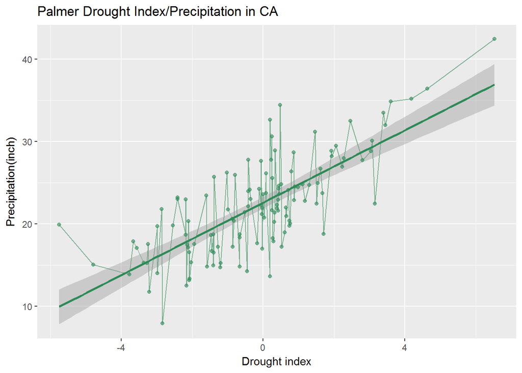

```r
ggplot(data = CA)+
  geom_line(mapping = aes(x = D.Value , y = R.Value), color = "seagreen4", alpha=0.6)+
  geom_smooth(mapping = aes(x = D.Value , y = R.Value), color = "seagreen4", method = "lm")+
  geom_point(mapping=aes(x = D.Value, y = R.Value), color = "seagreen4",alpha = 0.6)+
  labs(
    title = "Palmer Drought Index/Precipitation in CA",
    x ="Drought index",
    y ="Precipitation(inch)"
  )
```

Pearson correlation: strength of the linear relationship between two variables

```r
#The Pearson product-moment correlation coefficient
#is a measure of the strength of the linear relationship between two variables.
res <- cor.test(CA$D.Value, CA$R.Value, method = "pearson")
res
```

```
##
##  Pearson's product-moment correlation
##
## data:  CA$D.Value and CA$R.Value
## t = 12.129, df = 121, p-value < 2.2e-16
## alternative hypothesis: true correlation is not equal to 0
## 95 percent confidence interval:
##  0.6487821 0.8113720
## sample estimates:
##       cor
## 0.7407377
```

Distance correlation: distance correlation measures both linear and nonlinear association between two random variables or random vectors. Distance correlation coefficient is zero if and only if the random vectors are independent

```r
#distance covariance is a measure of dependence between two paired random vectors of arbitrary
#The population distance correlation coefficient is zero if and only if the random vectors are independent.
#distance correlation measures both linear and nonlinear association between two random variables
#The test decision is obtained via permutation bootstrap, with R replicates
res2 <- dcor(CA$D.Value, CA$R.Value)
res2
```

```
## [1] 0.6893273
```

# Raw Data on Drought/Precipitation in Washington

```r
WA <- read.csv("WA.csv", header = TRUE, stringsAsFactors = FALSE)
head(WA)
```

| Date | R.Value | D.Value |
| --- | --- | --- |
| 1895 | 35.76 | -0.67 |
| 1896 | 49.17 | 0.55 |
| 1897 | 50.59 | 1.54 |
| 1898 | 35.08 | -0.92 |
| 1899 | 52.08 | 1.85 |
| 1900 | 45.41 | 1.70 |

This is a method for fitting a smooth curve between two variables versus year.

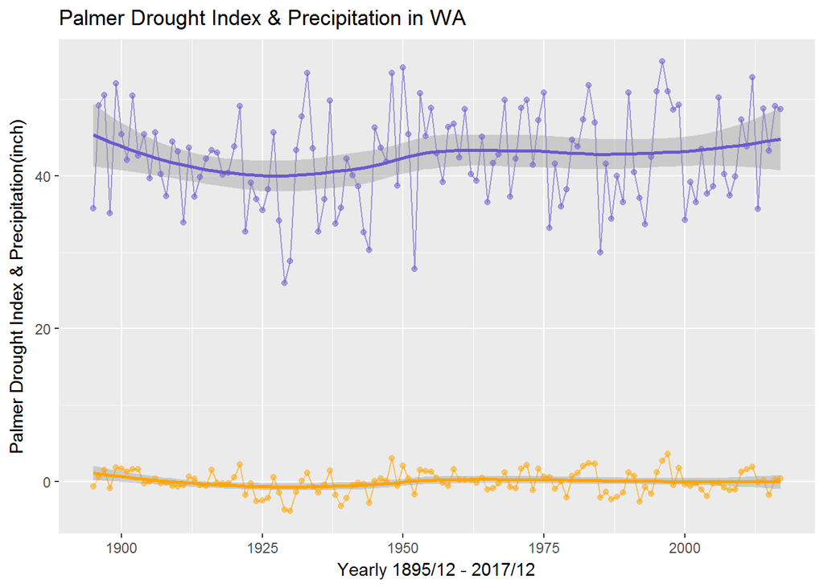

```r
#All year without grouping, fitting curve regression
#This is a method for fitting a smooth curve between two variables,
#or fitting a smooth surface between an outcome and up to four predictor variables
ggplot(data = WA)+
  geom_line(mapping = aes(x = Date , y = D.Value), color = "orange", alpha=0.6)+
  geom_smooth(mapping = aes(x = Date , y = D.Value), color = "orange", method = "loess")+
  geom_line(mapping = aes(x = Date , y = R.Value), color = "slateblue", alpha=0.6)+
  geom_smooth(mapping = aes(x = Date, y = R.Value), color = "slateblue", method = "loess" )+
  geom_point(mapping=aes(x = Date, y = D.Value), color = "orange",alpha = 0.5)+
  geom_point(mapping = aes(x = Date, y = R.Value), color = "slateblue", alpha = 0.5)+
  labs(
    title = "Palmer Drought Index & Precipitation in WA",
    x ="Yearly 1895/12 - 2017/12",
    y ="Palmer Drought Index & Precipitation(inch)"
  )
```

This is a method for fitting a linear line between two variables versus year.

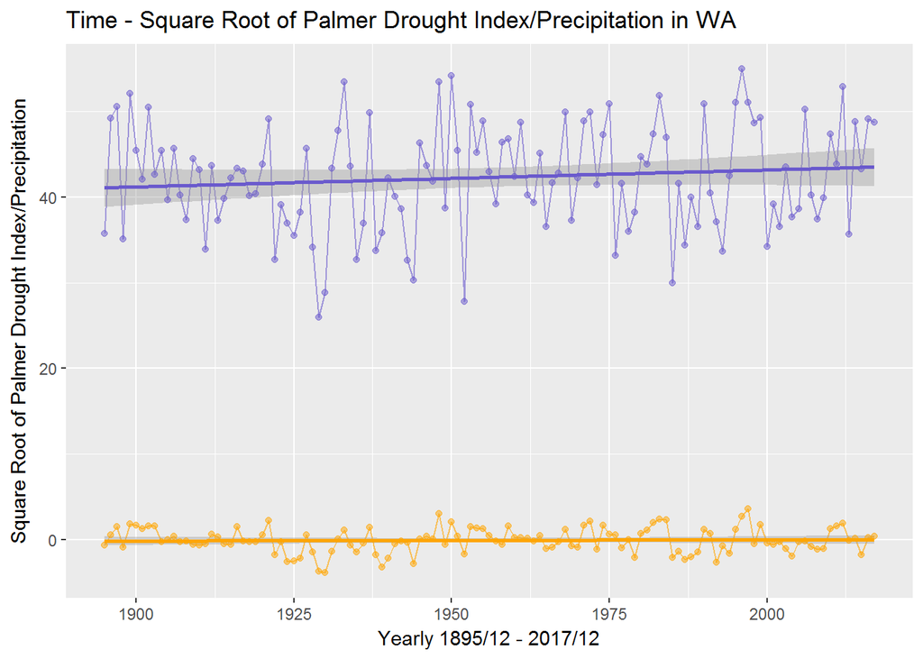

```r
#All year without grouping, fitting linear regression
ggplot(data = WA)+
  geom_line(mapping = aes(x = Date , y = D.Value), color = "orange", alpha=0.6)+
  geom_smooth(mapping = aes(x = Date , y = D.Value), color = "orange", method = "lm")+
  geom_line(mapping = aes(x = Date , y = R.Value), color = "slateblue", alpha=0.6)+
  geom_smooth(mapping = aes(x = Date, y = R.Value), color = "slateblue", method = "lm" )+
  geom_point(mapping=aes(x = Date, y = D.Value), color = "orange",alpha = 0.5)+
  geom_point(mapping = aes(x = Date, y = R.Value), color = "slateblue", alpha = 0.5)+
  labs(
    title = "Time - Square Root of Palmer Drought Index/Precipitation in WA",
    x ="Yearly 1895/12 - 2017/12",
    y ="Square Root of Palmer Drought Index/Precipitation"
  )
```

Linear regression summary for precipitation in WA

```r
WA_R_LM <- lm(WA$R.Value ~ WA$Date)
summary(WA_R_LM)
```

```
##
## Call:
## lm(formula = WA$R.Value ~ WA$Date)
##
## Residuals:
##      Min       1Q   Median       3Q      Max
## -15.7763  -4.5940   0.2268   4.4851  11.9795
##
## Coefficients:
##             Estimate Std. Error t value Pr(>|t|)
## (Intercept)  3.72484   31.03702   0.120    0.905
## WA$Date      0.01973    0.01586   1.243    0.216
##
## Residual standard error: 6.247 on 121 degrees of freedom
## Multiple R-squared:  0.01262,    Adjusted R-squared:  0.004455
## F-statistic: 1.546 on 1 and 121 DF,  p-value: 0.2161
```

Linear regression summary for Drought in WA

```r
WA_D_LM <- lm(WA$D.Value ~ WA$Date)
summary(WA_D_LM)
```

```
##
## Call:
## lm(formula = WA$D.Value ~ WA$Date)
##
## Residuals:
##     Min      1Q  Median      3Q     Max
## -3.7846 -0.8288 -0.1002  1.1804  3.6286
##
## Coefficients:
##              Estimate Std. Error t value Pr(>|t|)
## (Intercept) -2.603399   7.180747  -0.363    0.718
## WA$Date      0.001294   0.003671   0.353    0.725
##
## Residual standard error: 1.445 on 121 degrees of freedom
## Multiple R-squared:  0.001027,   Adjusted R-squared:  -0.007229
## F-statistic: 0.1243 on 1 and 121 DF,  p-value: 0.725
```